# Plot Legend Key

2020-04-10 10:48:07

# Purpose

The various plots generated by the tool are shown below, by type, with a description of the major points.

## Disclaimer

The CAST is a Causal Assessment Screening Tool. Its intended to assist the City and its agents to rapidly screen and identify the causes of biological impairment in a given waterbody, and thereby assist with prioritizing restoration and protection actions. Due the CAST’s reliance on currently available and sometimes incomplete data, however, it is not intended to be a final arbiter on causal assessments analyses, nor does it represent any commitments by the City to perform any specific projects, studies, or other actions.

## Box Plots, General

Box plots are used in many of the graphical representations of the data. Below is the USGS standard key for box plots (https://owi.usgs.gov/blog/boxplots/).

Some box plots are rotated 90 degrees to allow for more values to be included on the plot.

Some box plots include additional points that are color coded. These points are placed on the plot to show the distribution of select groups; e.g., reference, cluster, sites with better biological scores, target site, etc. The points are placed using the “jitter” command. The jittering adds a small amount of random variation (x and y) to the location of the points so they are easier to visualize. Thus the points should not be considered as exact locations and will be different each time the plots are generated.

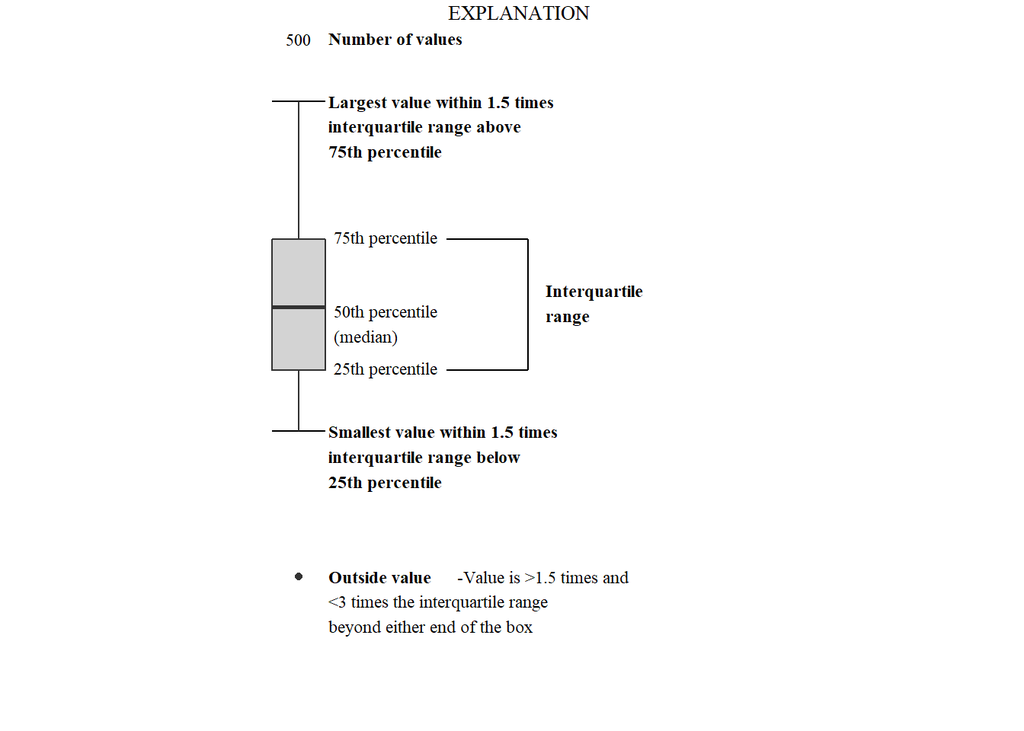

## Site Info

### Map, Static

The static map displays all sites in entire region of interest alont with NHD+ flowlines.

All sites (gray), comparator sites (light blue), and target site (red) are ploted on the map. Reference sites are marked with a dark blue outline.

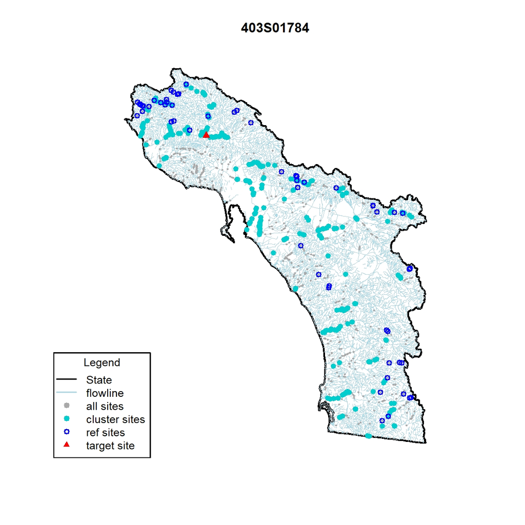

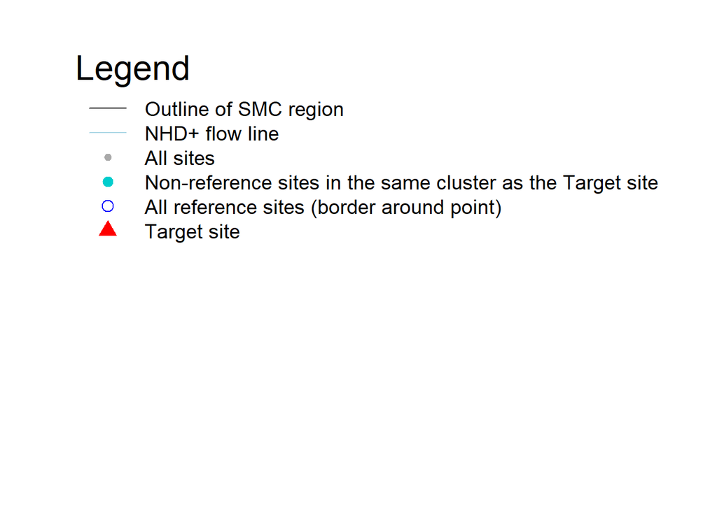

### Map, Interactive

The interactive map behaves much like Google Earth.

The points have the same color coding as the static map.

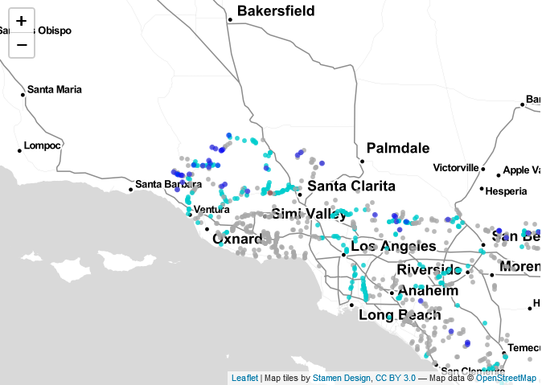

### Potential Anthropogenic Alteration Plots

Bar plots for target site with metrics from StreamCat. Most plots have panels or facets that subdivide the data into categories. The numbers above the bars is the value of the bar.

The color of the bars is a shade of red to associated it with the “target” site.

No scoring of data from these plots.

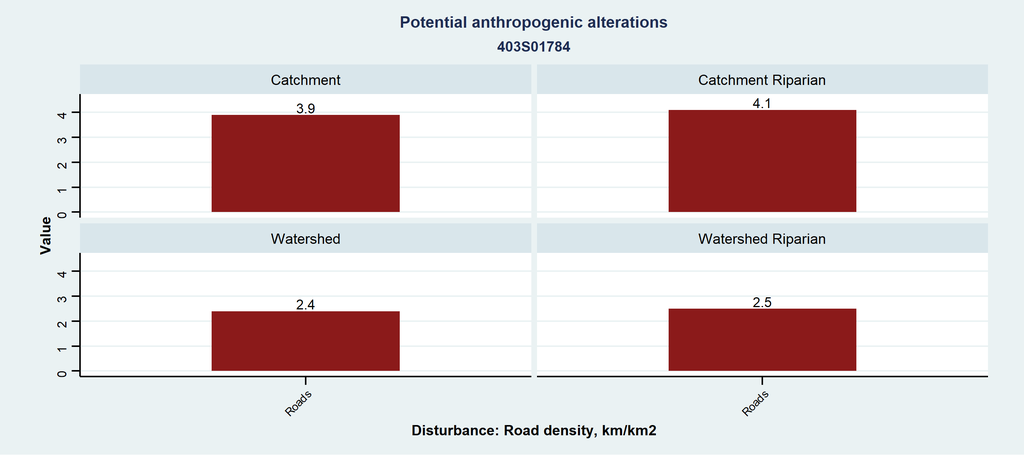

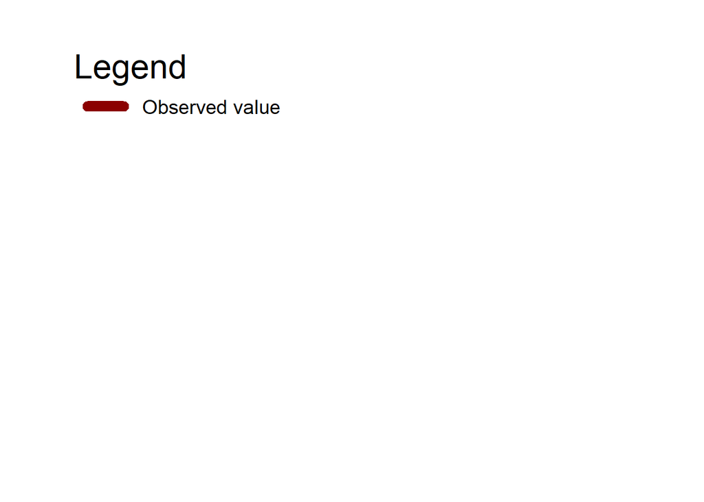

## Candidate Causes

Box plots by parameter.

Comparator sites values for non-degraded biological scores are points on the plot. The target site is a red triangle.

No scoring of data from these plots.

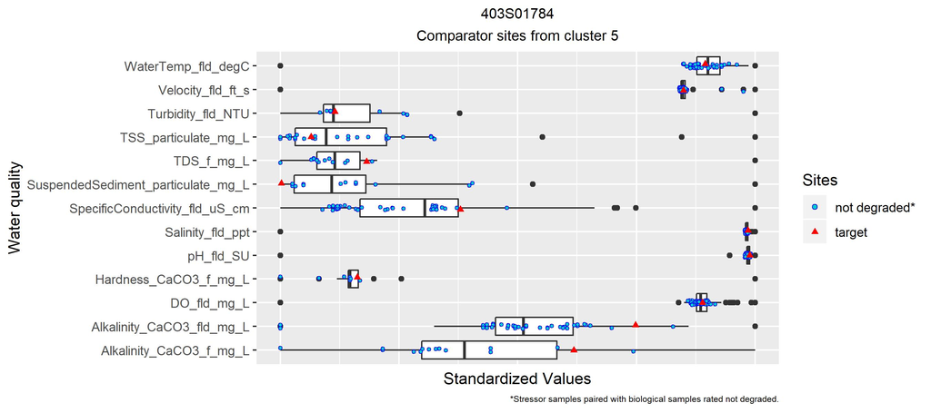

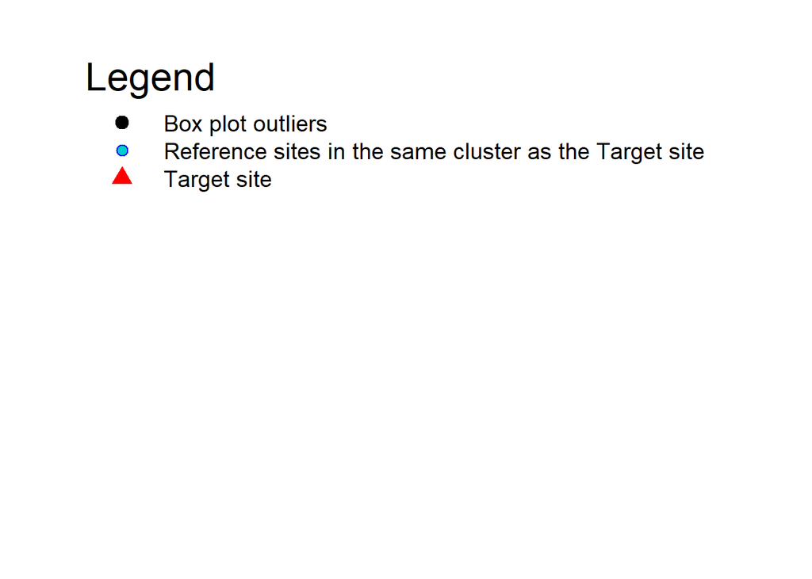

## CoOccurrence

### Box Plot

Box plot of specific conductivity.

Scoring based on the 50th and either the upper (75th) or lower (25th) quartile of the distribution of parameter values of comparator sites.

The score lines are black dotted lines and the target site value is the thicker dashed red line. Between the black lines is a score of 0. Values outside of the lines are scored as 1 or -1 depending on the expected direction of the parameters response to increasing perturbation.

Only comparator sites with higher biological scores are included on the plot. The points have been grouped as degraded and non-degraded.

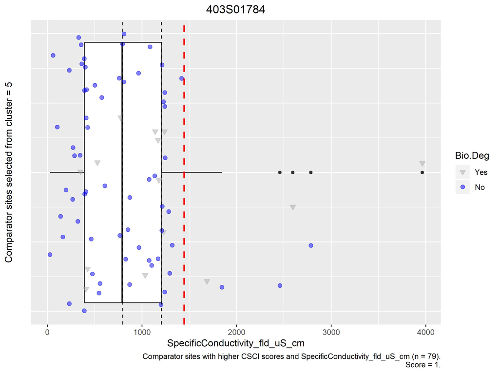

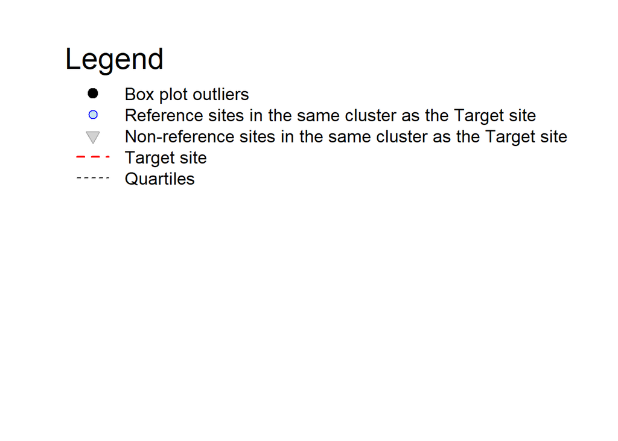

### Stressor Response Curve

Stressor-response of parameter of interest.

Scoring based on the 50th and 20th quartiles of the distribution of parameter values of comparator sites with measured values for the parameter of interest and CSCI scores.

The score lines are black dotted lines and the target site value is the thicker dashed red line. The red dashed line indicates where the target site parameter value is to be placed on the blue curve. Values between the black lines is a score of 0. Values outside of the lines are scored as 1 or -1 depending on the expected direction of the parameters response to increasing perturbation.

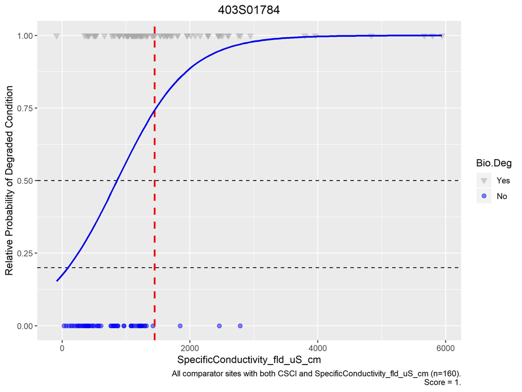

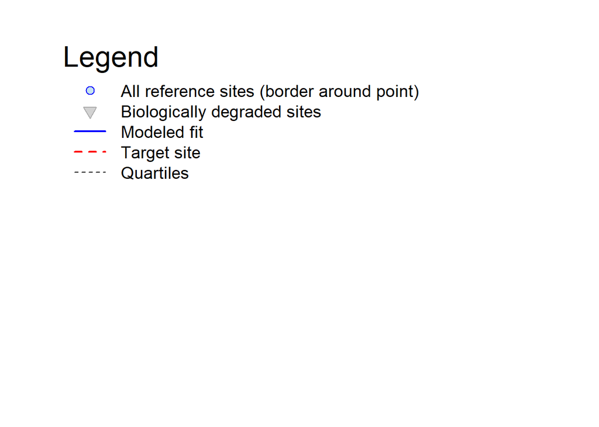

## Stressor-Response

Scattplot with linear regression fit and 75% prediction interval.

Several layers of data are overlaid on this plot of the biological value and parameter of interest.

The target site is a red triangle. All sites are denoted as gray points. Comparator sites are a lighter blue color. Any samples with biological scores of non-degraded are notes with a dark blue outline.

The lines represent the linear regression fit with 75th prediction intervals. The lines in black are using all sites. The lines in the lighter blue represent the same analysis with only comparator sites.

The regression lines, r-square values, number of records, and scores are shown below the plots.

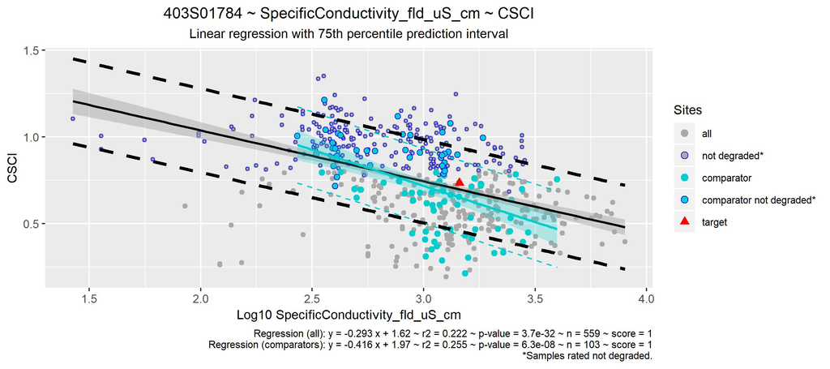

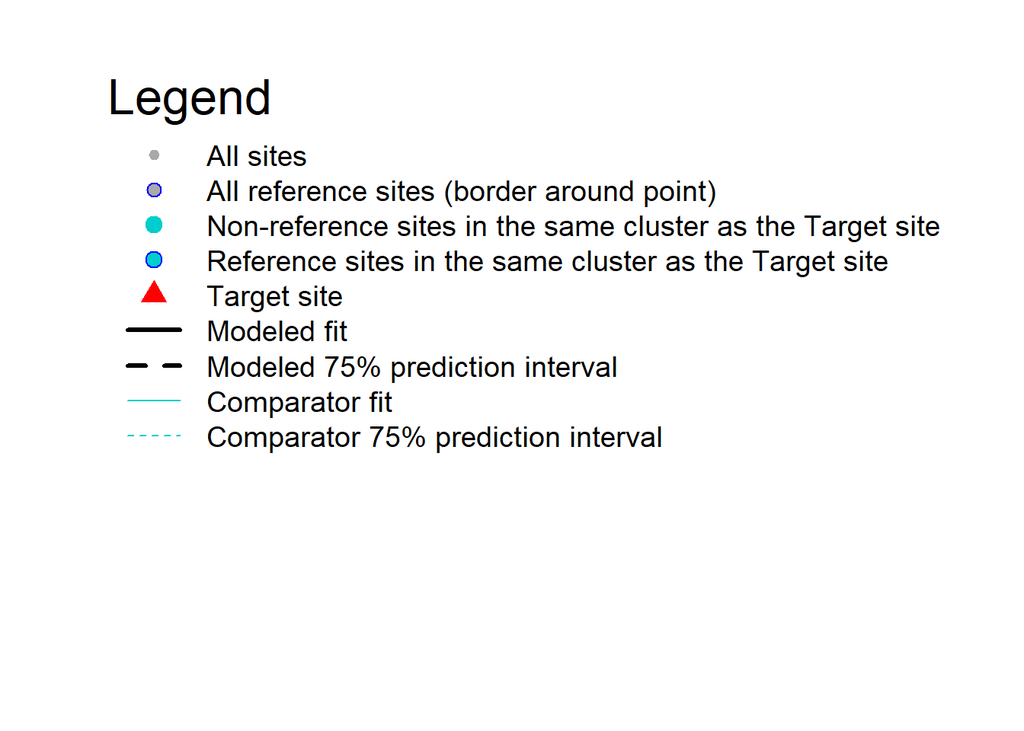

## Time Sequence

Bar plots of values vs. time.

Plots are intended to aid the user in visualizing the relative sampling time frames of the biological sample and parameter of interest.

Values for the parameter of interest and biological scores are represented by the height of the bars.

No scoring of data from these plots.

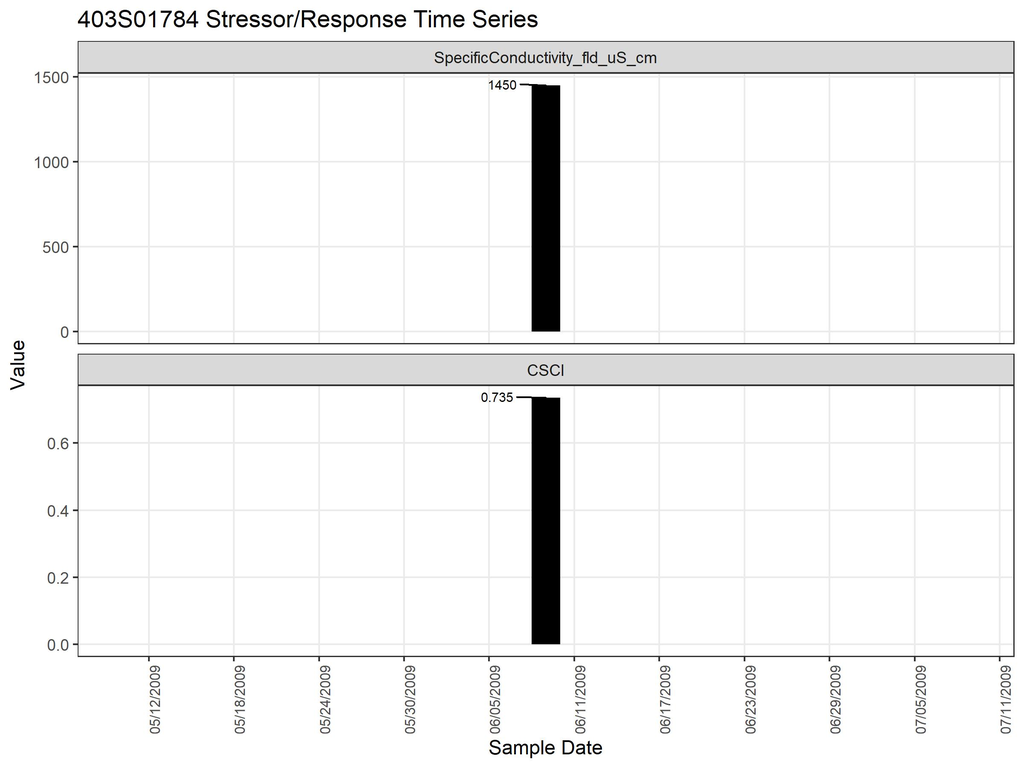

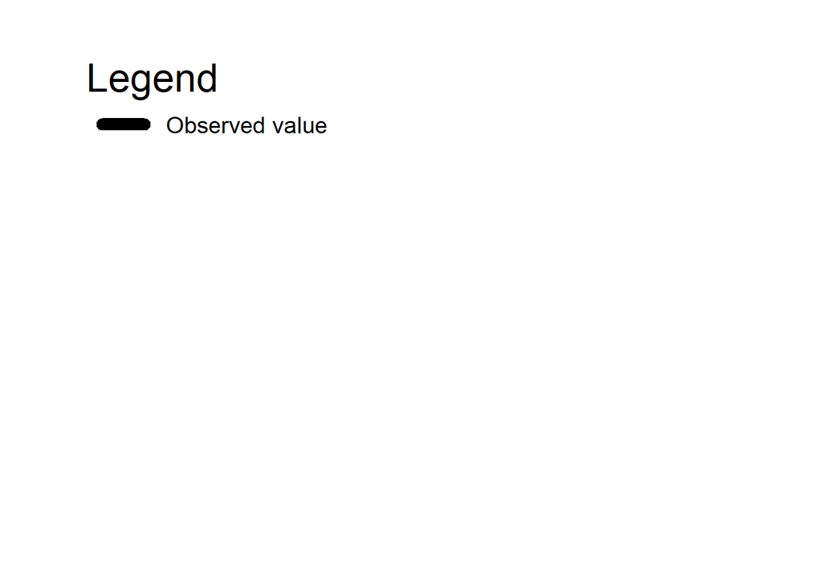

## Verified Predictions

Box plots of relative abundance, by taxa grouping. Taxa groupings are taxa considered tolerant or intolerant to the parameter of interest.

Only samples with better biological scores than the target site are used to generate the plot.

Site biological scores are classified as either degraded or not degraded.

Scoring based on the 50th and either the upper (75th) or lower (25th) quartile of the distribution of the relative abundance of taxa groupings in teh samples from comparator sites.

The score lines are black dotted lines and the target site value is the thicker dashed red line. Values between the black lines is a score of 0. Values outside of the lines are scored as 1 or -1 depending on the expected direction of the parameters response to increasing perturbation.

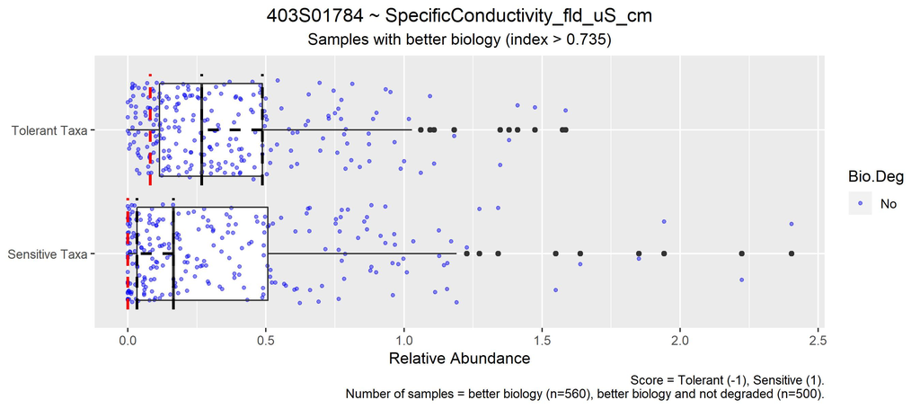

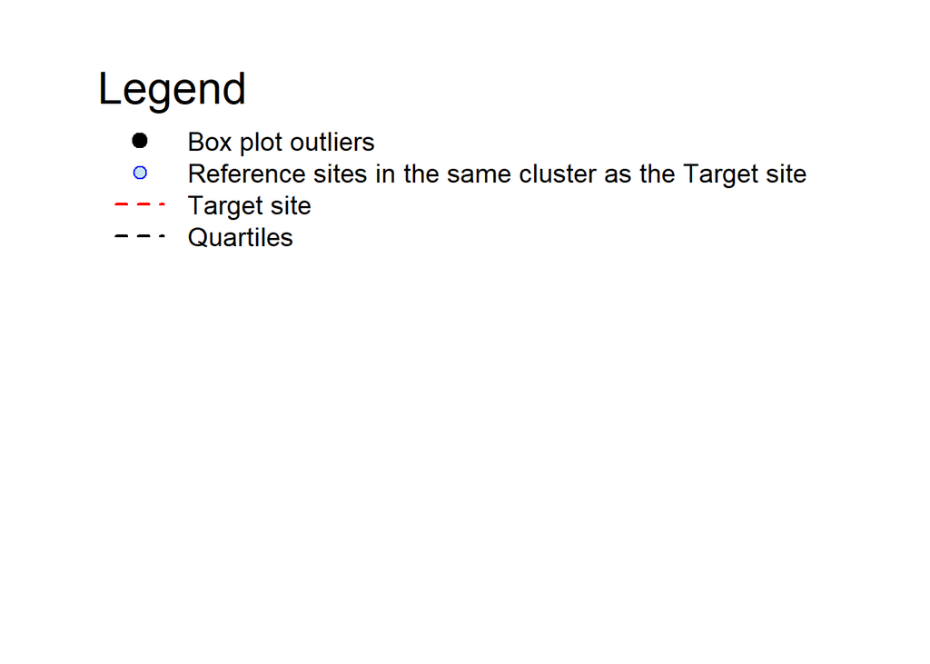